# HOMEWORK 01

G01: Betti, D’Arrigo, Masci, Mata Naranjo

# Part 1 - The Bayes Classifier

### 2. Find (with pen and paper) the Bayes classification rule $h_{opt}(x)$.

It can be proven that under the following conditions:

$$\begin{equation}
Y \in \{0, 1\}
\end{equation}$$

$$\begin{equation}
X \in \mathbb{R}
\end{equation}$$

the optimal classifier is:

$$\begin{equation}
h_{opt}(x) = \mathbb{I}(f_{opt}(x) - 1/2 \geq 0)
\end{equation}$$

In order to estimate the optimal Bayes classification rule we have to derive $f_{opt}(x)$ by using the Bayes Rule:

$$\begin{equation}
\begin{split}
f_{opt}(x)
&= \mathbb{E}(Y=1|X=x) = \mathbb{P}(Y=1|X=x) = \\
&= \frac{\mathbb{P}(X|Y=1)\mathbb{P}(Y=1)}{\mathbb{P}(X|Y=1)\mathbb{P}(Y=1)+\mathbb{P}(X|Y=0)\mathbb{P}(Y=0)} = \\
&\stackrel{i}{=} \frac{\mathbb{P}(X|Y=1)}{\mathbb{P}(X|Y=1)+\mathbb{P}(X|Y=0)} = \\
&\stackrel{ii}{=} \frac{\mathbb{I}_{[-1, 3]}(x)}{\mathbb{I}_{[-1, 3]}(x)+\mathbb{I}_{[-3, 1]}(x)}
\end{split}
\end{equation}$$

where we have used that (i) $P(Y=0) = P(Y=1)$ and (ii) $(X|Y=0) \sim Unif(-3, 1)$ and $(X|Y=1) \sim Unif(-1, 3)$. So finally we have that:

$$\begin{equation}
h_{opt}(x) = \mathbb{I}\bigg(\frac{\mathbb{I}_{[-1, 3]}(x)}{\mathbb{I}_{[-1, 3]}(x)+\mathbb{I}_{[-3, 1]}(x)} - \frac{1}{2} \geq 0\bigg)
\end{equation}$$

### 3. Simulate n = 250 data from the joint data model p(y, x) = p(x | y) · p(y) described above, and then:

#### a. Plot the data together with the regression function that defines $h_{opt}(x)$

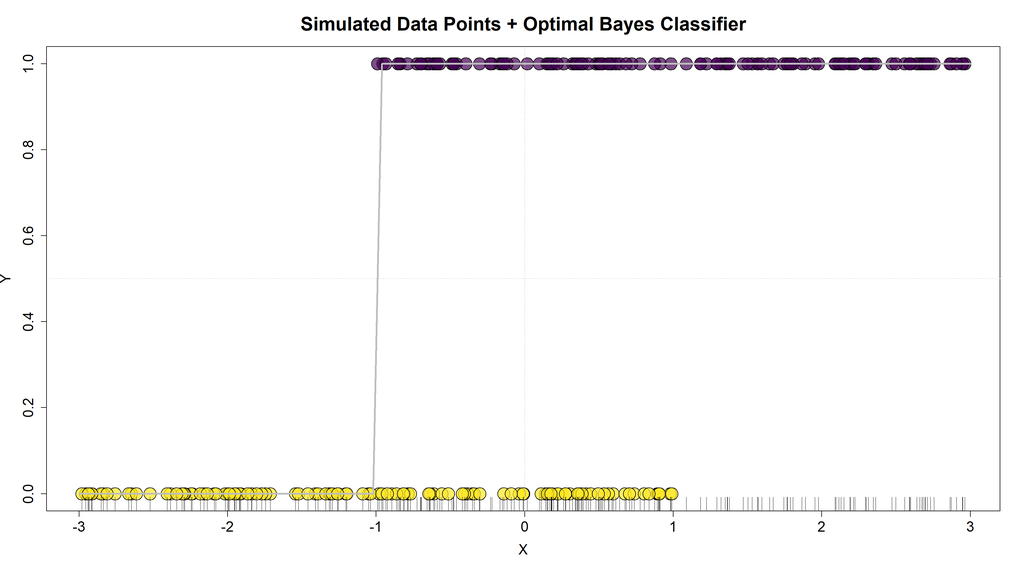

```r
# Generate Random Data
n <- 250
y <- sample(c(0,1), size=n, replace=TRUE, prob=c(.5,.5))
x_given_y <- c()
for (yi in y){
  if (yi==0){
    x <- runif(1, -3, 1)
  } else {
    x <- runif(1, -1, 3)
  }
  x_given_y <- c(x_given_y, x)
}

# Optimal Bayes Classifier
h.opt <- function(x) {

  f.opt = (ifelse((x<=3&x>=-1), 1, 0))/(ifelse((x<=3&x>=-1), 1, 0) + ifelse((x<=1&x>=-3), 1, 0))
  res = ifelse(f.opt-.5>=0, 1, 0)
  return(res)
}

# Plot + Regression Function
mycol = viridis(7, alpha = .7)
plot(x = x_given_y, y = y, bg= ifelse(y == 1, mycol[1], mycol[7]),
     pch=21, xlab="X", ylab = "Y", main="Simulated Data Points + Optimal Bayes Classifier", cex=3,
     cex.lab=1.5, cex.axis=1.5, cex.main=2)
abline(h = 0.5, lty = 3, col = gray(.8))
abline(v = 0, lty = 3, col = gray(.8))
rug(x_given_y)
curve(h.opt(x), from=-3, to=3, add = TRUE, col="gray", lwd=3)
```

#### b. Evaluate the performance of the Bayes Classifiers on these simple (only 1 feature!) data

The performance evaluation will be done using the binary loss function (which is the loss function used to derived the $h_{opt}()x$ function used to construct this Bayes Classifier):

```r
# Loss Function
loss <- function(y.actual, y.pred) {

  res = sum(y.actual != y.pred)
  return(res)
}

print(paste("Bayes Classifier Loss:", loss(y, h.opt(x_given_y))))
```

```
## [1] "Bayes Classifier Loss: 59"
```

```r
print(paste("Relative Bayes Classifier Loss:", loss(y, h.opt(x_given_y))/length(y)))
```

```
## [1] "Relative Bayes Classifier Loss: 0.236"
```

#### c. Apply any other classifier of your choice to these data and comparatively comment its performance

In this section we will choose another Classifier to compare its performance against that of the Bayes Classifier. The most obvious option at this point seems to be the Logistic Regression, so we will give this Classifier a try:

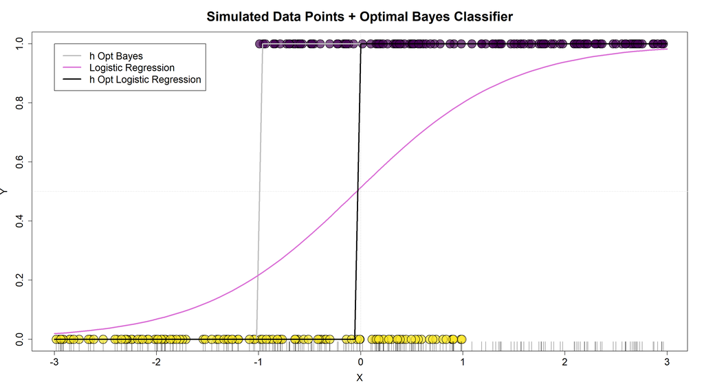

```r
logistic_regression <- function(x, y) {

  data = data.frame(y, x)
  fit_logit <- glm(y ~ ., data = data, family = "binomial")
  params = coef(fit_logit)
  return(params)
}

logit_func <- function(x, parameters=params) 1/(1 + exp(-(parameters[1]+parameters[2]*x)))

params = logistic_regression(x=x_given_y, y=y)

# Plot + Regression Function
plot(x = x_given_y, y = y, bg= ifelse(y == 1, mycol[1], mycol[7]),
     pch=21, xlab="X", ylab = "Y", main="Simulated Data Points + Optimal Bayes Classifier", cex=3,
     cex.lab=1.5, cex.axis=1.5, cex.main=2)
abline(h = 0.5, lty = 3, col = gray(.8))
abline(v = 0, lty = 3, col = gray(.8))
rug(x_given_y)
curve(h.opt(x), from=-3, to=3, add = TRUE, col="gray", lwd=3)
curve(logit_func(x, parameters=params), from=-3, to=3, add = TRUE, col="orchid", lwd=3)
curve(round(logit_func(x, parameters=params)), from=-3, to=3, add = TRUE, col="black", lwd=3)
legend(x=-3,, y=1,
       legend=c("h Opt Bayes", "Logistic Regression", "h Opt Logistic Regression"),
       #legend=c("1", "2", "3"),
       col=c("gray", "orchid", "black"), cex=1.5, lty=1, lwd=3)
```

```r
print(paste("Logistic Regression Classifier Loss:", loss(y, round(logit_func(x=x_given_y, parameters=params)))))
```

```
## [1] "Logistic Regression Classifier Loss: 68"
```

```r
print(paste("Relative Logistic Regression Classifier Loss:", loss(y, round(logit_func(x=x_given_y, parameters=params)))/length(y)))
```

```
## [1] "Relative Logistic Regression Classifier Loss: 0.272"
```

#### d. Who’s the best after 1000 simulations?

In order to compare both classifiers we will perform 1000 simulations and estimate the loss for each of the random samples.

```r
M = 1000
res_bayes = rep(NA, M)
res_log = rep(NA, M)

for(sim in 1:M){

  #if(sim%%10 == 0){
  #  print(sim)
  #}
  # Simulate Random Data
  n <- 250
  y <- sample(c(0,1), size=n, replace=TRUE, prob=c(.5,.5))
  x_given_y <- c()
  for (yi in y){
    if (yi==0){
      x <- runif(1, -3, 1)
    } else {
      x <- runif(1, -1, 3)
    }
    x_given_y <- c(x_given_y, x)
  }

  # Make predictions with Logistic Regression
  params = logistic_regression(x=x_given_y, y=y)
  res_log[sim] = loss(y, round(logit_func(x=x_given_y, parameters=params)))

  # Make predictions with Bayes
  res_bayes[sim] = loss(y, h.opt(x_given_y))

}

print(paste("Average Bayes Classifier Loss:", mean(res_bayes)))
```

```
## [1] "Average Bayes Classifier Loss: 62.392"
```

```r
print(paste("Average Logistic Regression Classifier Loss:", mean(res_log)))
```

```
## [1] "Average Logistic Regression Classifier Loss: 61.663"
```

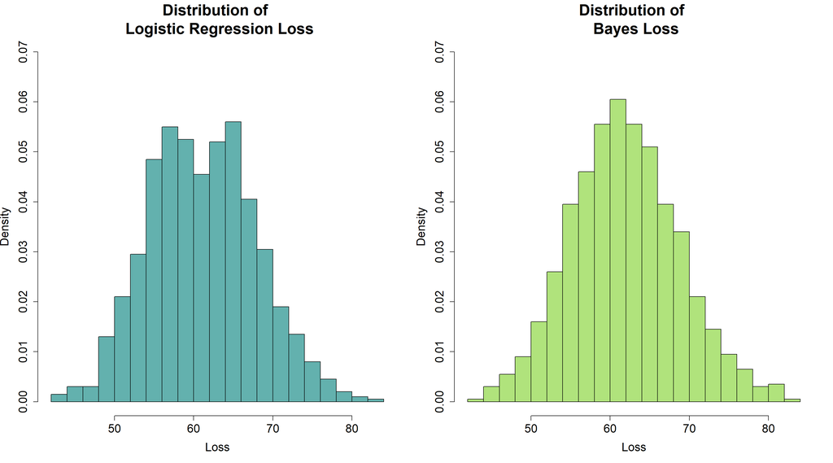

```r
par(mfrow = c(1:2))
hist(res_log, prob=TRUE, main="Distribution of \n Logistic Regression Loss", xlab="Loss", col=mycol[4], ylim = c(0, 0.07), breaks=20, cex.lab=1.5, cex.axis=1.5, cex.main=2)
hist(res_bayes, prob=TRUE, main="Distribution of \n Bayes Loss", xlab="Loss", col=mycol[6], ylim = c(0, 0.07), breaks=20, cex.lab=1.5, cex.axis=1.5, cex.main=2)
```

The logisitic regression seems to outperform the bayes classifier, but not by much. The reason for which we consider that the logistic regression is able to classify better us because it it able to handle data points that fall in the interval $x \in [-1, 1]$ in a more flexible manner, while the Bayes Classifier will always assign these points to the class $Y=1$. Theoretically, the Bayes approach should be the ideal classifier (since the data points are equally distirbuted among $Y=1$ and $Y=0$ in this interval), however since our data generating process only generates 250 points, the real disitrbution in the $[-1, 1]$ interval is probably not equally distributed.